# final_lab

312188881

12 7 2021

#Q_1

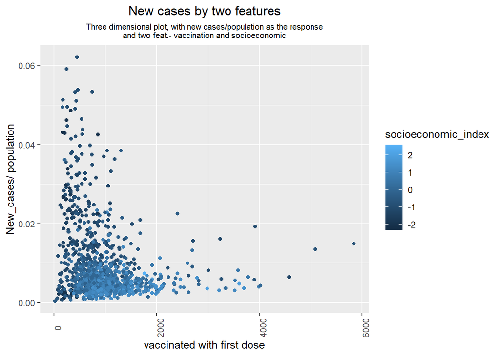

##In this plot I have chosen to examine the features of first dose vaccination and the socioeconomic_index. We can see that most of the population,for vaccination, are in the values of 0 to 1500. Interesting to see that most points with high values of the response variable are with a low socioeconomic index. In addition we can see the points where the vaccination is close to zero the socioeconomic index is low.

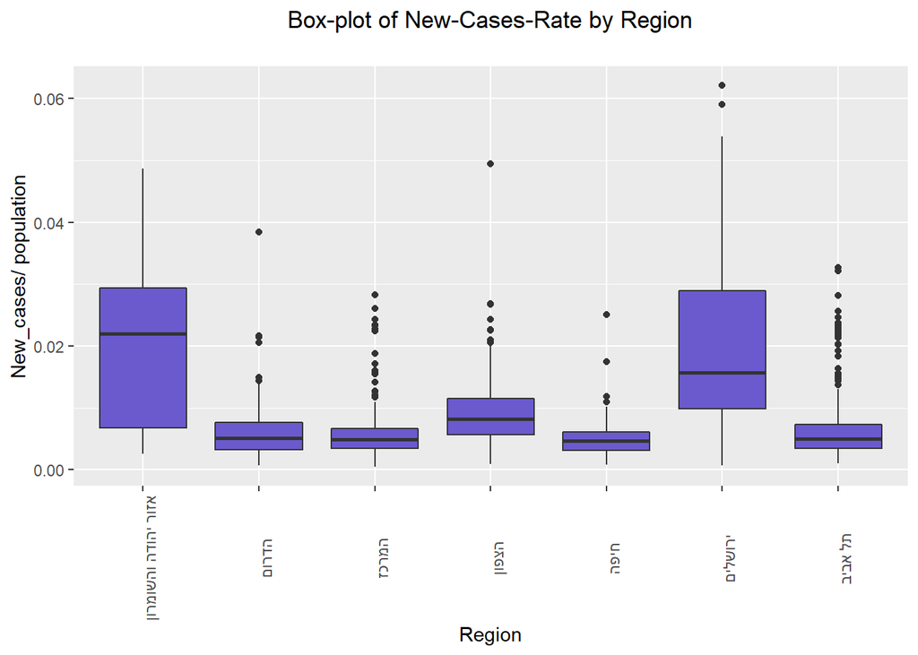

#Q_2.1

```r
ridge <- function(train_x, train_y, lambda){
  y = train_y
  x <- as.matrix(train_x)
  I <- diag(nrow = ncol(x)+1,ncol = ncol(x)+1)
  intercept <- rep(1, length(y))
  x <- cbind(intercept, x)
  beta <- solve((t(x) %*% x) + (lambda * I)) %*% t(x) %*% y
  return(beta)
}
```

#Q_2.2

```r
cv_ridge <- function(x, y, lambda = NA, train_size = 0.7){
  set.seed(89)
  inds <- as.numeric(sample(rownames(x_training_set),0.7*length(x_training_set$town_pop_denisty)))
  train_x <- x[inds,]
  #train_x <- na.replace(train_x)
  train_y <- y[inds]

  test_x <- x[-inds,]
  test_y <- y[-inds]

  mse_lst <- c()
  lambda_lst <- c()
  intercept <- rep(1, length(test_y))
  test_X <- cbind(intercept, test_x)

  for (i in 1:length(lambda)) {
    fit <- as.vector(ridge(train_x,train_y,lambda[i]))
    pred <- fit %*% t(test_X)
    mse = sqrt(mean((pred - test_y)^2))
    mse_lst[i] = mse
    lambda_lst[i] = lambda[i]
  }
  model_par <- cbind(mse_lst,lambda_lst)
  model_par <- model_par[order(model_par[,1],decreasing = T),]
  model_mse <- model_par[1,1]
  model_lambda <-model_par[1,2]
  best_model = ridge(train_x,train_y,model_lambda)

  return(list(best_model = best_model, model_mse = model_mse, model_lambda = model_lambda))
}
#cleaning the data
temp_train <- as.data.frame(select(train, -"town_eng.y",-"town",-"town_code",-"agas_code", -"new_cases",-"population",-"pop_over50",-"pop_over70"))
temp_train <- dummy_cols(temp_train, select_columns = c("mahoz"),remove_selected_columns = TRUE)
temp_train <- as.data.frame(sapply(temp_train, as.numeric))
temp_train <- na.replace(temp_train)
x_training_set<- as.data.frame(sapply(temp_train, as.numeric)) #x mat for func
lambda = seq(.1,100,.1)

optimal_model <- cv_ridge(x_training_set,y_dat,lambda,0.7)

results <- data.frame("model_mse"=optimal_model[["model_mse"]], "model_lambda" =optimal_model[["model_lambda"]])
rownames(results)<- NULL

kbl(optimal_model[["best_model"]], digits = 10,caption = "Model's coefficients")
```

Model’s coefficients

| intercept | 0.0001944678 |
| --- | --- |
| accumulated_vaccination_first_dose | 0.0000009319 |
| town_pop_denisty | 0.0000000141 |
| town_diabetes_rate | -0.0000000412 |
| town_perc_clalit | -0.0001002544 |
| town_income | 0.0000001378 |
| town_bagrut | -0.0001839759 |
| town_socioeconomic_index | -0.0009724997 |
| agas_socioeconomic_index | 0.0000000228 |
| pop_over20 | -0.0000006191 |
| town_east_coord | 0.0000012272 |
| town_north_coord | 0.0000000189 |
| mahoz_אזור יהודה והשומרון | 0.0000963202 |
| mahoz_הדרום | 0.0005176924 |
| mahoz_המרכז | 0.0003552698 |
| mahoz_הצפון | -0.0005020274 |
| mahoz_חיפה | -0.0007856798 |
| mahoz_ירושלים | 0.0009133686 |
| mahoz_תל אביב | -0.0004004759 |

```r
results %>%
  kbl(caption = "Model's parameters",) %>%
  kable_material_dark("hover",full_width = T)
```

Model’s parameters

| model_mse | model_lambda |
| --- | --- |
| 0.006703 | 100 |

#I have chosen to take out some of the features. Such as new_cases and population since they make up the response variable. pop_over70, pop_over50 and pop_over 20 were exhibiting high levels of multicollinearity, so I took out two of them. I also changed the categorical variable “mahoz” to a dummy variable. The results of the optimal model, after cross validation, can be seen in the tables above.

#Q_2.3

```r
full_data <- ridge(x_training_set, y_dat,100)
intercep <- rep(1, length(y_dat))
full_x_set <- cbind(intercep, x_training_set)
pred <- t(full_data) %*% t(full_x_set)
resid <- t(y_dat - pred)
#correlation
cor_mat <- as.data.frame(t(cor(resid,full_x_set)))
cor_mat<-na.omit(cor_mat)
colnames(cor_mat)<- "Correlation"
cor_mat <-cor_mat[order(cor_mat$Correlation,decreasing = T),, drop = FALSE]

kbl(cor_mat, digits = 7,caption = "correlation between the residuals and the variables")
```

[output not shown]

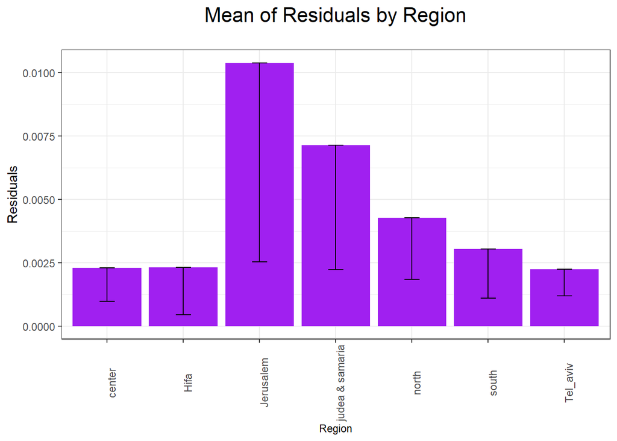

```r
#Residuals and sd for each region
resid_mahoz <- cbind(resid,full_x_set)
resid_mahoz_1 <- resid_mahoz %>%  filter(resid_mahoz$`mahoz_אזור יהודה והשומרון` == 1)
resid_mahoz_2 <- resid_mahoz %>%  filter(resid_mahoz$mahoz_הדרום == 1)
resid_mahoz_3 <- resid_mahoz %>%  filter(resid_mahoz$mahoz_המרכז ==1)
resid_mahoz_4 <- resid_mahoz %>%  filter(resid_mahoz$mahoz_הצפון ==1)
resid_mahoz_5 <- resid_mahoz %>%  filter(resid_mahoz$mahoz_חיפה == 1)
resid_mahoz_6 <- resid_mahoz %>%  filter(resid_mahoz$mahoz_ירושלים ==1)
resid_mahoz_7 <- resid_mahoz %>%  filter(resid_mahoz$`mahoz_תל אביב` == 1)
#means
mean_risid_1 <- round(mean(abs(resid_mahoz_1$resid)),6)
mean_risid_2 <- round(mean(abs(resid_mahoz_2$resid)),6)
mean_risid_3 <- round(mean(abs(resid_mahoz_3$resid)),6)
mean_risid_4 <- round(mean(abs(resid_mahoz_4$resid)),6)
mean_risid_5 <- round(mean(abs(resid_mahoz_5$resid)),6)
mean_risid_6 <- round(mean(abs(resid_mahoz_6$resid)),6)
mean_risid_7 <- round(mean(abs(resid_mahoz_7$resid)),6)
#sd
sd_risid_1 <- round(sqrt(var(resid_mahoz_1$resid)),6)
sd_risid_2 <- round(sqrt(var(resid_mahoz_2$resid)),6)
sd_risid_3 <- round(sqrt(var(resid_mahoz_3$resid)),6)
sd_risid_4 <- round(sqrt(var(resid_mahoz_4$resid)),6)
sd_risid_5 <- round(sqrt(var(resid_mahoz_5$resid)),6)
sd_risid_6 <- round(sqrt(var(resid_mahoz_6$resid)),6)
sd_risid_7 <- round(sqrt(var(resid_mahoz_7$resid)),6)

resid_dat <- as.data.frame(cbind(mean_risid_1,mean_risid_2,
      mean_risid_3,mean_risid_4,mean_risid_5,mean_risid_6,mean_risid_7))
resid_dat <- as.data.frame(t(rbind(resid_dat,c("judea & samaria", "south","center","north","Hifa","Jerusalem","Tel_aviv"),c(sd_risid_1,sd_risid_2,sd_risid_3,sd_risid_4,sd_risid_5,sd_risid_6,sd_risid_7))))
resid_dat$V3<- as.numeric(resid_dat$V3)
resid_dat$V1<- as.numeric(resid_dat$V1)

ggplot(resid_dat, aes(x=V2,y=V1)) + geom_bar(stat = "identity",fill="purple")+
  geom_errorbar(aes(ymin=abs(V1-V3), ymax= abs(V1), width=.2))+
labs(title = "Mean of Residuals by Region", subtitle = "",y = "Residuals", x = "Region")+
  theme_bw()+
  theme(plot.title = element_text(hjust = 0.5, size = rel(1.5)),axis.text.x = element_text(angle = 90),
        plot.subtitle = element_text(hjust = 0.5, size = rel(0.8)),
        axis.title.y = element_text(angle = 90, size = rel(1),),
        axis.title.x = element_text(angle = 0,size = rel(0.8)))
```

##In this plot we can see the mean residuals by each region. we can see that residuals vary quite a lot between the different regions and also with in themselves, ehibiting highest standard deviations.

```r
#Q_2.4

y = y_dat
x <- as.matrix(full_x_set)
I <- diag(nrow = ncol(x),ncol = ncol(x))
w <- x %*% solve((t(x) %*% x) + (100 * I)) %*% t(x)
###
x_agas_1 <- cbind(rownames(train),train) %>% filter(agas_code==1)
ind_agas <- as.numeric(x_agas_1$`rownames(train)`)
w_agas <- w[,c(2,13,16,21,26,31,77,87,94,108,129,147,159,171,175,189,
193,209,245,453,469,750,848,1113,1117,1121,1160)]

w_sum <- as.data.frame(colSums(abs(w_agas)))
w_sum$city <- c(2,13,16,21,26,31,77,87,94,108,129,147,159,171,175,189,
193,209,245,453,469,750,848,1113,1117,1121,1160)
#w_sum <-w_sum[order(w_sum$`rowSums(abs(w))`,decreasing = T),, drop = FALSE]

#largest weights
w_sum<- w_sum[order(w_sum$`colSums(abs(w_agas))`,decreasing = T),]
r_name <- w_sum$city[1:5] #top five cities indexes

x_dat_mean <- as.data.frame(colMeans(full_x_set[r_name,]))#mean of the 5 cities
meancol <- as.data.frame(colMeans(full_x_set))#mean of all cities
colnames(x_dat_mean) <- "var_mean_5"
colnames(meancol) <- "var_mean_all"
join_means <- cbind(round(x_dat_mean,5),round(meancol,5))[2:10,]
most_influence <- train[r_name,] #

most_influence %>%
  kbl(caption = "The cities with the most infulence",) %>%
  kable_material_dark("hover",full_width = T)
```

The cities with the most infulence

| town_code | agas_code | town | new_cases | accumulated_vaccination_first_dose | mahoz | town_pop_denisty | town_diabetes_rate | town_perc_clalit | town_income | town_bagrut | town_socioeconomic_index | agas_socioeconomic_index | pop_over20 | pop_over50 | pop_over70 | population | town_eng.y | town_east_coord | town_north_coord |
| --- | --- | --- | --- | --- | --- | --- | --- | --- | --- | --- | --- | --- | --- | --- | --- | --- | --- | --- | --- |
| 1224 | 1 | כוכב יאיר | 8 | 1011 | המרכז | 2874.1 | .. | 39.7 | 14589.465 | 86.56716 | 1.863 | 2.3549701 | 1623 | 930 | 224 | 2183 | KOKHAV YA’IR | 19978 | 68091 |
| 2560 | 1 | ערד | 189 | 1303 | הדרום | 209.7 | 71.2 | 29.8 | 7689.599 | 57.34266 | -0.389 | -0.7188107 | 3023 | 1439 | 581 | 4917 | ARAD | 22036 | 57414 |
| 9200 | 1 | בית שאן | 46 | 811 | הצפון | 2467.3000000000002 | 64.599999999999994 | 94.4 | 7533.838 | 70.46980 | -0.193 | 0.3270455 | 3072 | 1308 | 300 | 4458 | BET SHE’AN | 24696 | 71125 |
| 3570 | 1 | אריאל | 11 | 595 | אזור יהודה והשומרון | .. | 56.4 | 41.0 | 9010.143 | 75.86207 | 0.385 | 0.3808807 | 1689 | 923 | 312 | 2113 | ARI’EL | 21786 | 66790 |
| 1161 | 1 | רהט | 27 | 624 | הדרום | 2129.4 | 91.4 | 81.8 | 5389.092 | 55.40211 | -1.915 | -1.8374256 | 2938 | 483 | 66 | 6331 | RAHAT | 17657 | 58882 |

#This chart shows the five cities with the highest weights i.e most influential and their complete data.

```r
join_means %>%
  kbl(caption = "Model's Featrue means",) %>%
  kable_material_dark("hover",full_width = T)
```

Model’s Featrue means

|  | var_mean_5 | var_mean_all |
| --- | --- | --- |
| accumulated_vaccination_first_dose | 868.80000 | 941.92347 |
| town_pop_denisty | 19351.61397 | 9660.52200 |
| town_diabetes_rate | 17506.64207 | 4779.83060 |
| town_perc_clalit | 57.34000 | 48.84875 |
| town_income | 8842.42743 | 9135.47074 |
| town_bagrut | 69.12876 | 65.87162 |
| town_socioeconomic_index | -0.04980 | 0.07507 |
| agas_socioeconomic_index | 0.10133 | 9256.33938 |
| pop_over20 | 2469.00000 | 3404.55202 |

#Q_3 #For this section I have chosen to run a random forest model. I have discarded the same variables as before that were part of the response and the variables that were exhibiting high multicollinearity.

```r
test_feat <- read.csv("test_features.csv",encoding = "UTF-8")#reading test data
#cleaning the test data to match the training set
  test_feat_f <- as.data.frame(select(test_feat, -"town_eng.y",-"town",-"town_code",-"agas_code", -"population",-"pop_over50",-"pop_over70",-"X"))

#converting "mahoz" to dummy variable
test_feat_f <- dummy_cols(test_feat_f, select_columns = c("mahoz"),remove_selected_columns = TRUE)

test_feat_f <- as.data.frame(sapply(test_feat_f, as.numeric))
test_feat_f <- na.replace(test_feat_f)
rf_train_dat <- temp_train[,-(17)]
#splitting the training set to train and validation for the rmse prediction
set.seed(459)
rf_ind <- sample(rownames(rf_train_dat), 0.7*length(rf_train_dat$town_income))
rf_train_x <- rf_train_dat[rf_ind,]
rf_test_x <- rf_train_dat[-as.numeric(rf_ind),]
rf_train_y <- y_dat[as.numeric(rf_ind)]
rf_test_y <- y_dat[-as.numeric(rf_ind)]
#running a random forest model
rf_model <- randomForest(x = rf_train_x, y =rf_train_y, ntree = 100, do.trace = 1,mtry = 5)
rf_pred_train<- predict(rf_model,newdata = rf_test_x,type = 'response')#y_hat of traing
predict_rmse  <- sqrt(mean((rf_pred_train - rf_test_y)^2))#rmse estimation

predict_y <- predict(rf_model,newdata = test_feat_f,type = 'response')#test prediction

save(predict_y, predict_rmse, file = "312188881.rda")

#true_rmse = Metrics::rmse(actual = true_y, predicted = predict_y)
```